# IDA_HW6-Group66

987144, 987154 And 986384

December 16, 2019

# Homework 6: Models

# Exerise 1: Common probability distributions in R

# Binomial distribution

## Plot the binomial distribution

```
## # A tibble: 100 x 3
##    theta     k   value
##    <dbl> <int>   <dbl>
##  1   0.2     0 0.00472
##  2   0.2     1 0.0283
##  3   0.2     2 0.0815
##  4   0.2     3 0.149
##  5   0.2     4 0.196
##  6   0.2     5 0.196
##  7   0.2     6 0.155
##  8   0.2     7 0.0998
##  9   0.2     8 0.0530
## 10   0.2     9 0.0236
## # ... with 90 more rows
```

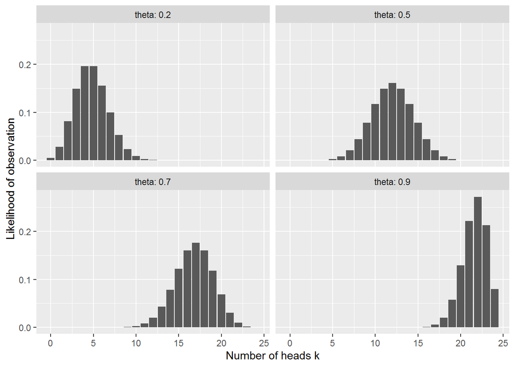

## Interpret the plot

The top left graph shows the likelihood of getting k heads (sucesses) if we repeat the experiement N = 24 times given the likelihood for each individual success is 0.2.

```r
##pbinom(0:5,5,0.5)
##dbinom(0:5,5,0.5)
binom <- tibble(
  theta = c(0.2,0.5,0.7,0.9),
  pro_value = dbinom(7, 24, theta)
)
binom
```

```
## # A tibble: 4 x 2
##   theta pro_value
##   <dbl>     <dbl>
## 1   0.2  9.98e- 2
## 2   0.5  2.06e- 2
## 3   0.7  3.68e- 5
## 4   0.9  1.66e-12
```

# Normal distribution

## Sample from the normal distribution and plot

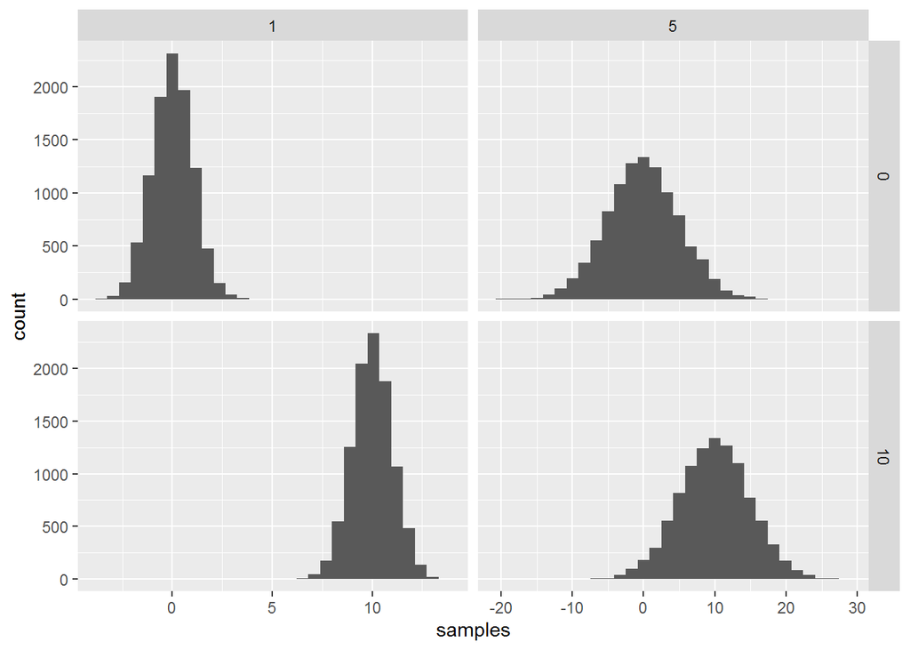

```r
n <- 10000
normt <- tibble(my = numeric(), stdd = numeric(), value = numeric())
for (thismy in c(0,10)) {
  for (thisstdd in c(1,5)) {
    normt <- add_row(normt,
                     my = thismy,
                     stdd = thisstdd,
                     value = rnorm(n, thismy, thisstdd)
                     )
  }
}

ggplot(data = normt, aes(value)) +
  geom_histogram() +
  facet_grid(my ~ stdd, scales = "free") +
  labs(
    x = "samples",
    y = "count"
  )
```

## Cumulative probability

```r
normt <- tibble(mu = numeric(), stdd = numeric(), value = numeric())

for (thismy in c(0,10)) {
  for (thisstdd in c(1,5)) {
    normt <- add_row(normt,
          mu = thismy,
          stdd = thisstdd,
          value = round(1- pnorm(0.5, thismy, thisstdd), digits = 3)
    )
  }
}

normt
```

```
## # A tibble: 4 x 3
##      mu  stdd value
##   <dbl> <dbl> <dbl>
## 1     0     1 0.309
## 2     0     5 0.46
## 3    10     1 1
## 4    10     5 0.971
```

## Explain these results

### Explaining intuitively and using the 68-95-99.7 rule

1. At mu = 10 and sd = 1 the possibility of all the number to be above is 0.5 is 1. (mu +/- 3sd) puts 99.7 perfect of points above 0.5.
2. At mu = 10 and sd = 5 the possibility of all the number to be above is 0.5 is 0.971. 50 perfect of points above 10 + Plus (mu - 2sd) put 47.7 percent. Which add s up to 97.7. The answer is 0.971 as the mu- 2sd = 0. the values between 0 to 0.5 creates the difference
3. At mu = 0 all the values below 0 which is 50 percent is removed. Now when the sd = 1. More values will fall between 0 to 0.5 compared to when sd = 5

# Exercise 2: The T-Test Model

## Load the avocado price data

```r
avocado_data <- read_csv(url('https://raw.githubusercontent.com/michael-franke/intro-data-analysis/master/data_sets/avocado.csv')) %>%
  # remove currently irrelevant columns
  select( -X1 , - contains("Bags"), - year, - region) %>%
  # rename variables of interest for convenience
  rename(
    total_volume_sold = `Total Volume`,
    small  = '4046',
    medium = '4225',
    large  = '4770',
  )
```

## Write the likelihood function in R

```r
Likelihood <- function(y1, y2, mu, sigma, delta) {
  map_dbl(delta, function(d) {
    prod(dnorm(y1, mu, sigma)) + prod(dnorm(y2, mu + d, sigma))
  }
  )
}

y1 <- avocado_data %>% filter(type %in% "organic")
y2 <- avocado_data %>% filter(type %in% "conventional")

Likelihood(y1$AveragePrice, y2$AveragePrice, 1.65, 0.3,  -0.5)
```

```
## [1] 0
```

```r
llh_ttest <- function(y1, y2, mu, sigma, delta) {
  map_dbl(delta, function(d) {
    sum(dnorm(y1, mu, sigma, log = T)) + sum(dnorm(y2, mu + d, sigma, log = T))
  }
  )
}

llh_ttest(y1$AveragePrice, y2$AveragePrice, 1.65,0.3 , -0.5)
```

```
## [1] -5006.292
```

## Plot aspects of the likelihood function

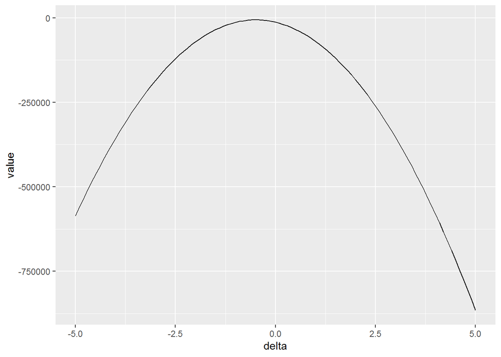

```r
p <- seq(-5, 4.9, by=0.1)

LogLik <- numeric(length=100)
for(i in 1:100){
  LogLik[i] <- llh_ttest(y1$AveragePrice, y2$AveragePrice, sigma = 0.4, mu = 1.65, delta =p[i])
}


delta <- seq (-5,5, by = 0.1)
tibble <- tibble(delta = delta, value = llh_ttest(y1$AveragePrice, y2$AveragePrice, sigma = 0.4, mu = 1.65, delta))
tibble %>%
ggplot(aes(x = delta, y = value)) + geom_line()
```

## Predictive function

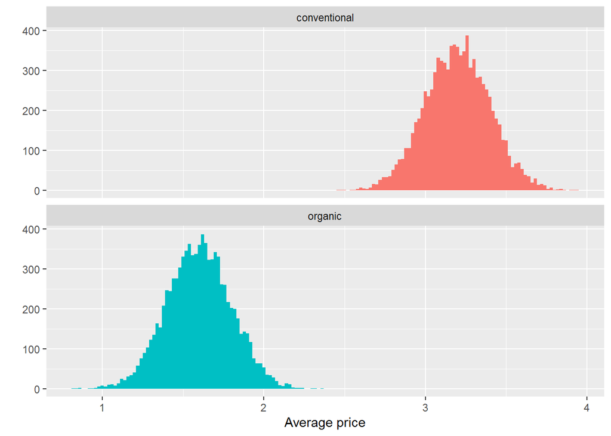

```r
randomsample <- function (type, mu, sigma, delta) {
  data <- as.data.frame(table(type))
  output <- tibble(type = character(), average_price = numeric())
  for(i in 1:length(data)) {
    if(data[i,1] == "organic")
      output <- add_row(output, type = data[i,1], average_price = rnorm(data[i,2], mu, sigma))
    else
      output <- add_row(output, type = data[i,1], average_price = rnorm(data[i,2], mu + delta, sigma))
  }
  output
}

plotsample <- function (mu, sigma, delta) {
  randomsample(avocado_data$type, mu, sigma, delta) %>%
    ggplot(aes(x = average_price, fill = type)) +
    geom_histogram(binwidth = 0.02) +
    facet_wrap(type ~ ., ncol = 1) +
    ylab('') +
    xlab('Average price') +
    theme(legend.position = "none")
}

plotsample(mu = 1.6, sigma = 0.2, delta = 1.6)
```

## Formulate a probabilistic belief

$these\ are\ the\ closest\ parameters\ for\ the\ last\ question\ \delta \sim Normal(-0.5, 0.1)$

# Exercise 3

## Urn model

There are 4 variables in the model of a single urn with an unkonwn population from which we draw (we draw white unicorns) without returning them (we only return black unicorns). N is the population size of unicorns = latent (unknown) variable K is the number of marked unicorn in the population = 20 n is the number of unicorns found during the 2nd visit = 24 k is the number of marked unicorns during the 2nd visit = 7

## Model Graph

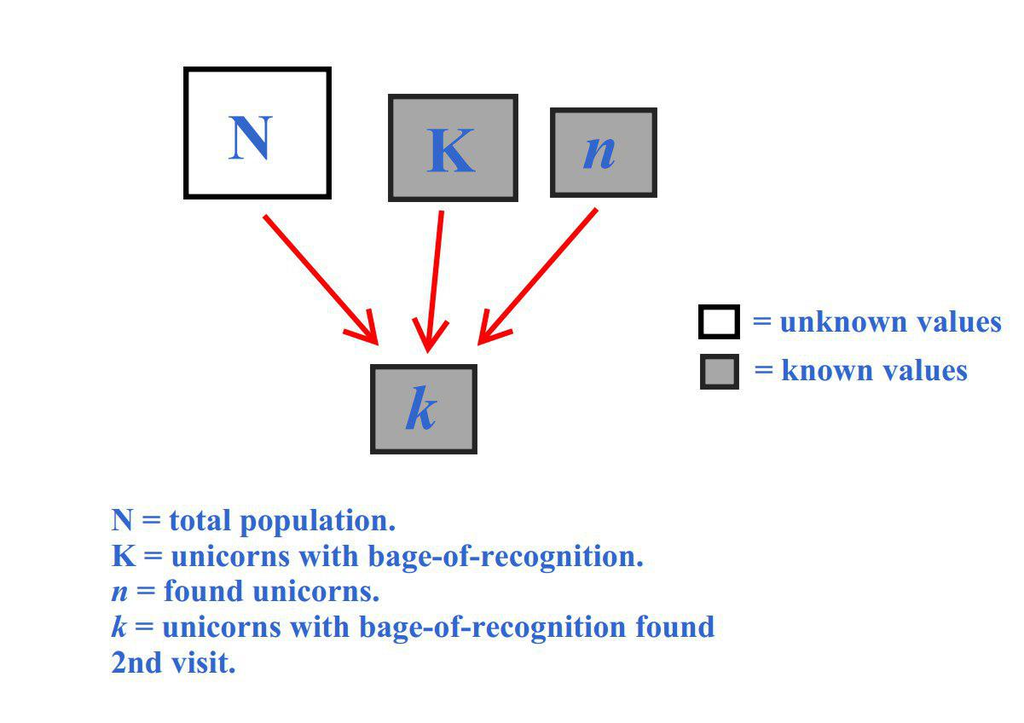

Model

## Likelihood function

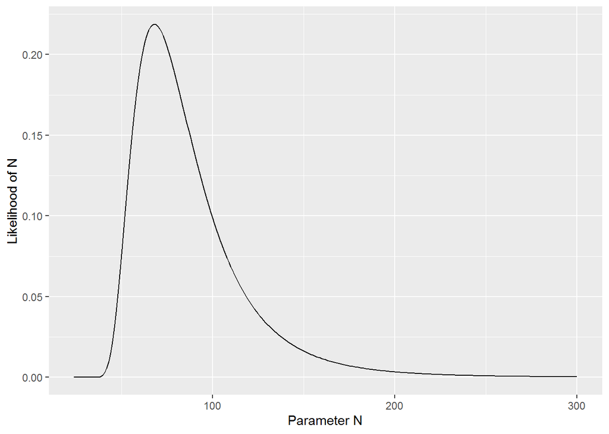

```r
K <- 20; n <- 24; k <- 7

test_dhyper <- function (N, K, n, k) {
  dhyper(k, K, N - K, n)
}

ggplot(data.frame(x = c(24, 300)), aes(x = x)) +
  stat_function(fun = test_dhyper, geom = "line", n = (300-24+1), args = list(
    K = K,
    n = n,
    k = k
  )) +
  scale_x_continuous(name = "Parameter N") +
  scale_y_continuous(name = expression("Likelihood of N"))
```

## Estimate the number of unicorns

Based on the plot of the likelihood function, we can conclude that the total amount of unicorns is between 65 and 70 given that the graph peaks in that range. If we were to zoom in (by changing the c(24,300) to c(55,75); and the n = (300-24+1) to n = (75-55+1) in the code), we would see the peak to be at 68 unicorns exactly.